# Polishing your Plots

2016-06-22

## Visual Appearance

So far have mostly discussed how to get the data displayed the way you want, focusing on the essence of the plot.

Themes give you a huge amount of control over the appearance of the plot, the choice of background colours, fonts and so on.

## Built-In Themes

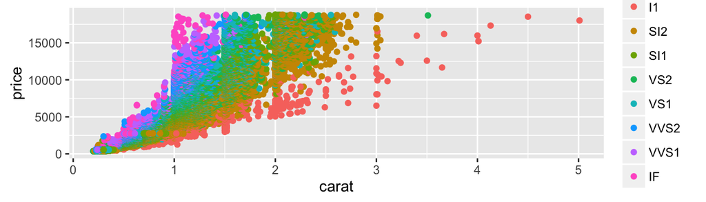

```r
p <- qplot(carat, price, data = diamonds, colour = clarity); p
```

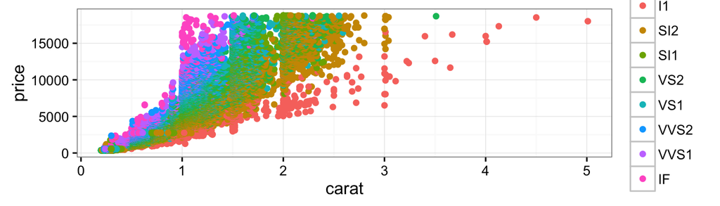

```r
p + theme_bw()
```

## `ggthemes` package

### Tufte theme

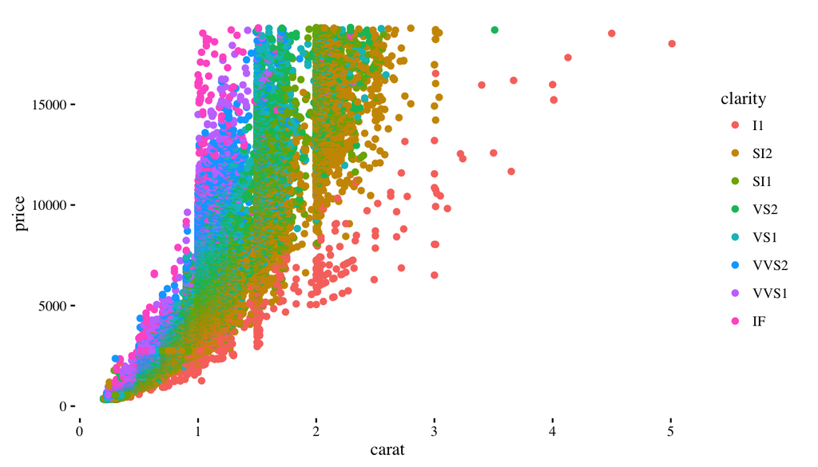

```r
library(ggthemes)
p + theme_tufte()
```

## `ggthemes` package

### Economist theme

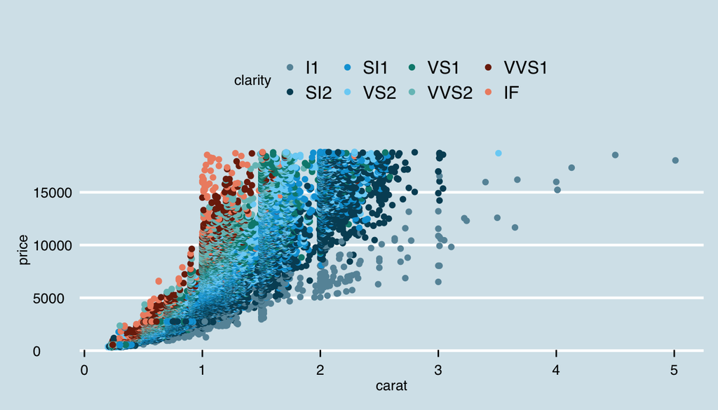

```r
p + theme_economist() + scale_colour_economist()
```

## `ggthemes` package

### Excel 2003 theme

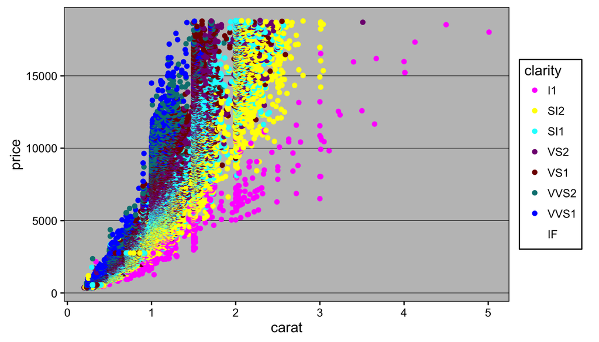

```r
p + theme_excel() + scale_colour_excel()
```

## `ggthemes` package

### Wall street journal theme

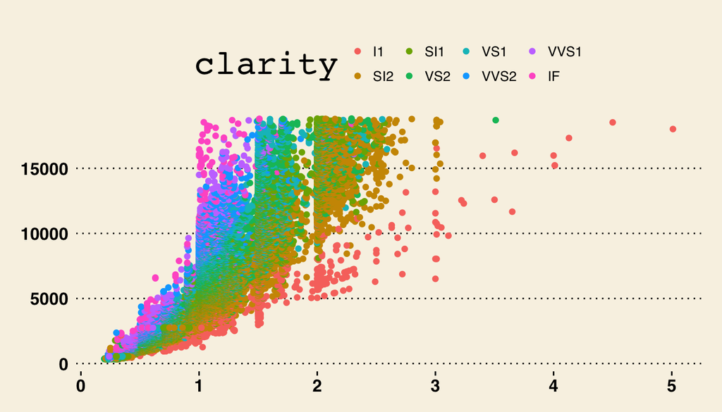

```r
p + theme_wsj()
```

## Setting Themes

You can set a theme for all plots:

```r
theme_set(theme_bw())
```

We can also take a look at options for each theme:

```r
theme_bw()
```

[output not shown]

[output cut: 217 more lines]

[output not shown]

## Plot Title

You can change this for an individual plot

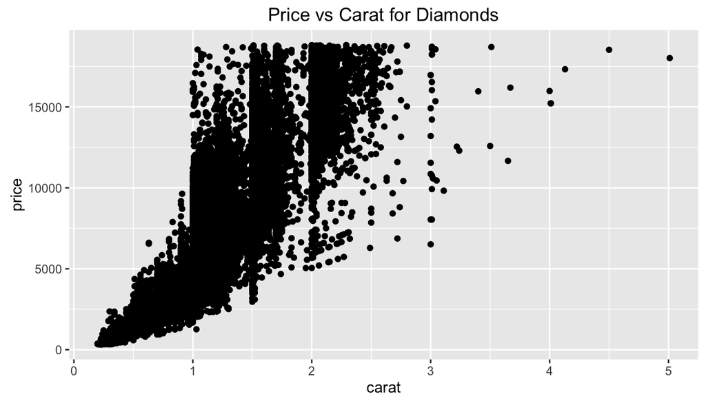

```r
qplot(carat, price, data = diamonds) +
    ggtitle("Price vs Carat for Diamonds")
```

## Elements

You can make your own theme, or modify an existing one.

Themes are made up of elements which can be one of:

- element_line
- element_text
- element_rect
- element_blank

This gives you a lot of control over plot appearance.

## Elements we can set

- **Axis**: axis.line, axis.text.x, axis.text.y, axis.ticks, axis.title.x, axis.title.y
- **Legend**: legend.background, legend.key, legend.text, legend.title
- **Panel**: panel.background, panel.border, panel.grid.major, panel.grid.minor
- **Strip**: strip.background, strip.text.x, strip.text.y

## Modifying a plot

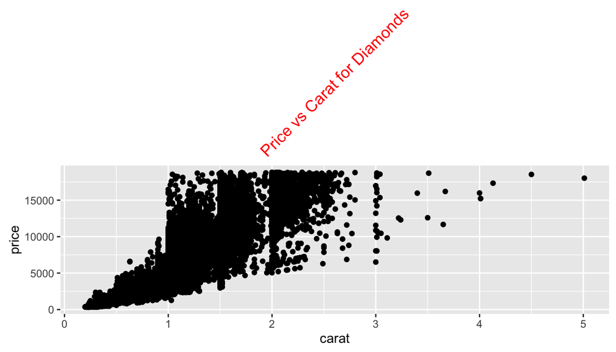

```r
p <- qplot(carat, price, data = diamonds) +
    ggtitle("Price vs Carat for Diamonds")
p + theme(plot.title = element_text(colour = "red", angle = 45))
```

## Removing Axes

We could also choose to remove all axes (helpful for maps):

```r
p + theme(
    axis.text.x = element_blank(),
    axis.text.y = element_blank(),
    axis.title.x = element_blank(),
    axis.title.y = element_blank(),
    axis.ticks.length = unit(0, "cm")
)
```

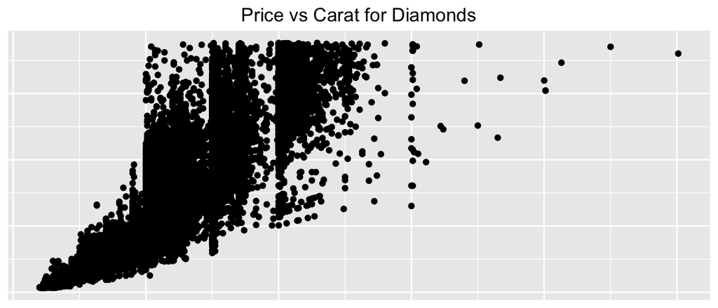

## Saving your Work

The `ggsave()` function will automatically save the last plot produced:

```r
qplot(price, carat, data = diamonds)

ggsave("diamonds.png")
ggsave("diamonds.pdf")
ggsave("diamonds.png", width = 6, height = 6)
```

We can also explicitly tell it which plot to save:

```r
dplot <- qplot(carat, price, data = diamonds)
ggsave("diamonds.png", plot = dplot, dpi = 72)
```

## Your Turn

1. Save a pdf of a scatterplot of price vs carat
2. Open up the pdf in Adobe Acrobat (or another PDF Reader)
3. Save a png of the same scatterplot